# Fuel and Pollution and Air Pollution Effects

Shuneng Wu, Marlon Bayer, Josephine Athappilly

11/14/2022

## What is this file for?

- This file will eventually become your project report for **P02: Exploratory Data Analysis**. Specifically, you will write rmarkdown to report your exploratory data analysis.
- Please see Canvas for more details.

## ACCESSING THE /source DIRECTORY

### Example 1: Source some code and run a function

```r
# Example 1: Note relative path, which can be read: Up one
# directory(..), down into source (/source), and
# then "source" an R file (data_access.R)
source("../source/data_access.R")
data_access_test()
```

```
## [1] "Hello: World!"
```

### Example 2: Initialize a variable and then use it

```r
# Example 1: This function was "sourced" above
msg <- data_access_test(" Morgan!")
```

> Hello: Morgan! Hope you have a good day!!

## ABOUT THIS FILE:

## Household Clean Fuel Reliance by Region (Chart 1)

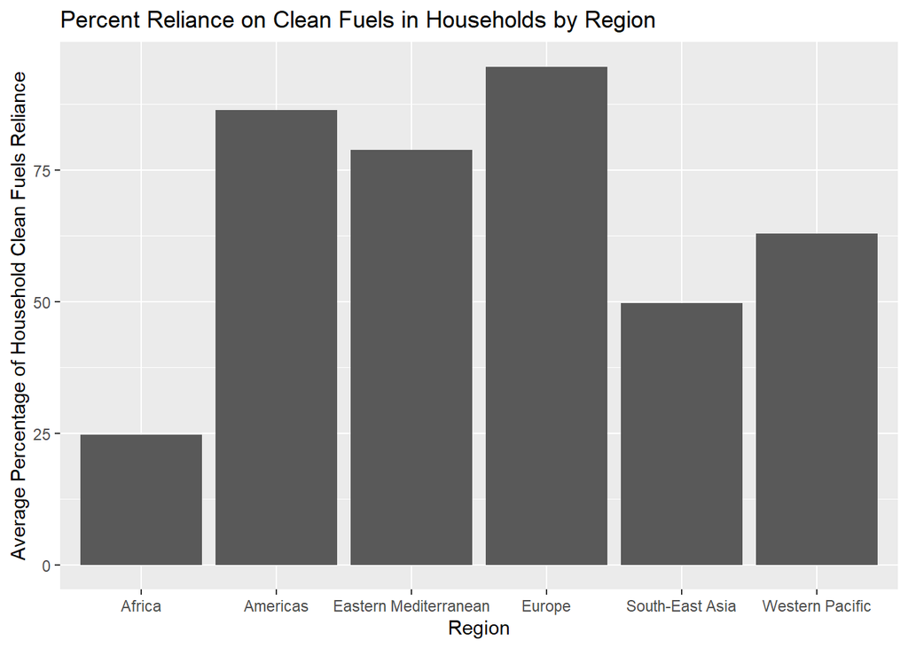

This chart shows the average percentage reliance on clean fuel sources in households across different world regions in the form of a bar chart. Of course, this is limited by the number of countries that WHO has this information on. From this chart, we can see that clean fuels are most prevalent in households in Europe and the Americas (which includes Caribbean countries). This prevalence is much decreased in Africa, which only has about a 25% average reliance. Using this in conjunction with the following map can help viewers compare the regions with worst air particle concentration with their use of clean fuels.

## PM2.5 Concentrations Worldwide (Chart 2)

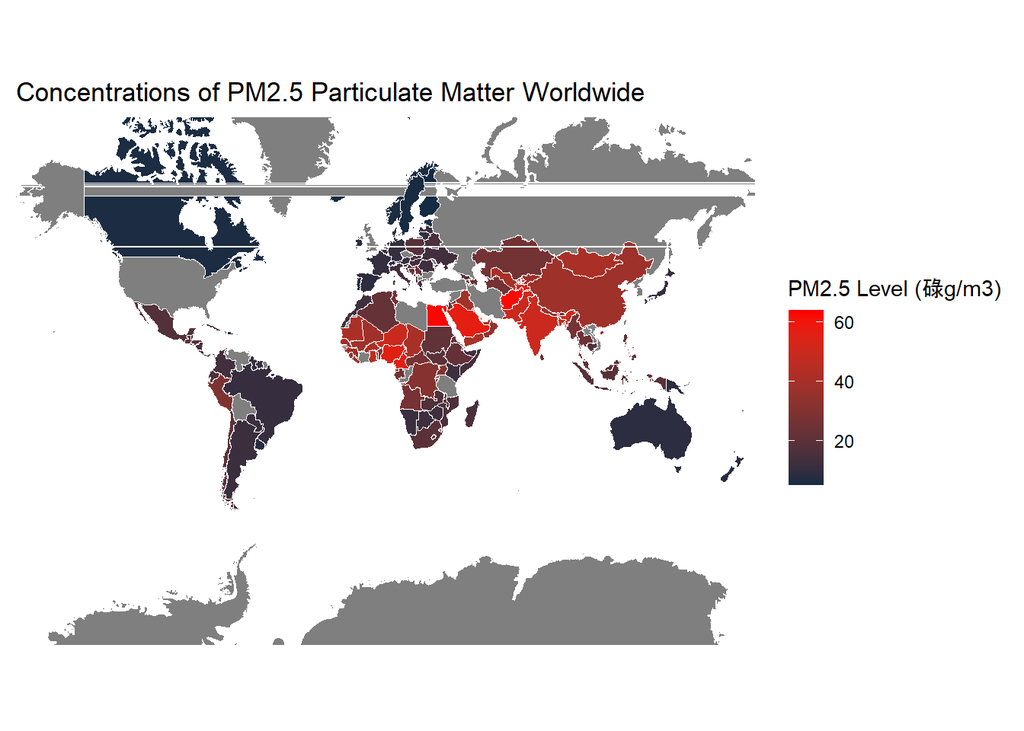

This map visually illustrates the concentration of certain particulates in ambient air around the world. The more red a country is, the higher the concentration, ie. the more air pollution they suffer. From the visualization, it is clear that Asia, the Middle East, and North Africa have many countries with high particulate levels. It’s interesting when comparing this to the previous chart, that Africa and Southeast Asia have low clean fuel reliance on average, whereas the Eastern Mediterranean region sees more clean fuel usage. There may be a correlation in the first two regions between low clean fuel reliance and poor air quality, but there is likely a different reason for the air pollution in Eastern Mediterranean.

## Reliance on Clean Fuels and Air Pollution-Related Deaths (Chart 3)

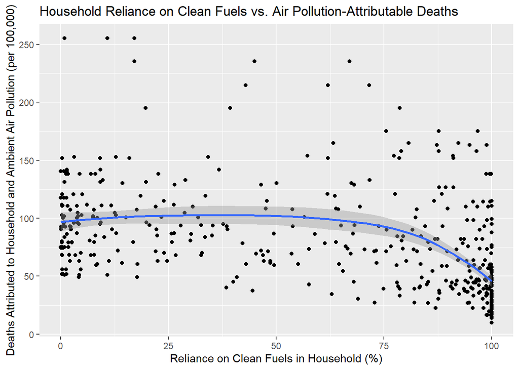

This scatterplot shows each country’s average reliance on clean household fuels and the death rate per 100,000 due to air-pollution related causes. The use of a trend line helps show how strong of a relationship there is between these two variables. There seems to be little relationship between the two when the clean fuel usage is between around 0 and 70%. After this point, the line begins to curve down, indicating a negative relationship between the two; as reliance on clean fuels increases, the deaths related to air pollution decrease.

## Dynamic Conclusion (Summary Scripts)

```
## $observations_clean_fuels
## [1] 17763
##
## $observations_mortality
## [1] 6588
##
## $observations_concentrations
## [1] 9450
##
## $avg_reliance_2019
## [1] 89.3
##
## $avg_reliance_rural
## [1] 75.5
##
## $avg_reliance_urban
## [1] 96.3
##
## $Region_most_reliance
## [1] "Europe"
##
## $Region_least_reliance
## [1] "Africa"
##
## $avg_mortality_2019
## [1] 12.05
##
## $Region_most_mortality
## [1] "Africa"
##
## $Region_lowest_mortality
## [1] "Europe"
##
## $avg_concentrations_2019
## [1] 19.57
##
## $avg_concentrations_urban
## [1] 19.775
##
## $avg_concentrations_rural
## [1] 17.715
##
## $Region_highest_concentrations
## [1] "Eastern Mediterranean"
##
## $Region_lowest_concentrations
## [1] "Western Pacific"
```

## Aggregate Tables

| Region | avg_concentration_rate | avg_mortality_rate | avg_reliance_rate |
| --- | --- | --- | --- |
| Africa | 29.455 | 24.810 | 7.80 |
| Americas | 12.840 | 6.925 | 94.45 |
| Eastern Mediterranean | 34.400 | 10.360 | 99.40 |
| Europe | 15.925 | 5.750 | 100.00 |
| South-East Asia | 26.485 | 22.240 | 63.60 |
| Western Pacific | 8.545 | 15.805 | 69.80 |

| Countries | avg_clean_fuels_rate | avg_concentration_rate | avg_mortality_rate |
| --- | --- | --- | --- |
| Afghanistan | 31.90 | 69.320 | 26.110 |
| Albania | 80.70 | 19.405 | 18.870 |
| Algeria | 99.70 | 22.490 | 5.565 |
| Andorra | 100.00 | 9.710 | NA |
| Angola | 49.50 | 26.305 | 20.245 |
| Antigua and Barbuda | 100.00 | 8.420 | 3.375 |
| Argentina | 99.90 | 13.060 | 6.030 |
| Armenia | 98.00 | 40.325 | 9.930 |
| Australia | 100.00 | 7.195 | 1.995 |
| Austria | 100.00 | 13.690 | 3.420 |
| Azerbaijan | 96.70 | 29.895 | 11.905 |
| Bahamas | 100.00 | 5.280 | 1.485 |
| Bahrain | 100.00 | 54.460 | 6.560 |
| Bangladesh | 23.40 | 49.025 | 29.290 |
| Barbados | 100.00 | 9.810 | 6.320 |
| Belarus | 99.50 | 17.150 | 6.460 |
| Belgium | 100.00 | 13.275 | 5.170 |
| Belize | 82.10 | 10.650 | 7.330 |
| Benin | 4.00 | 31.805 | 34.540 |
| Bhutan | 79.40 | 23.145 | 17.940 |
| Bolivia (Plurinational State of) | 85.70 | 26.450 | 17.595 |
| Bosnia and Herzegovina | 45.00 | 34.060 | 35.900 |
| Botswana | 63.90 | 14.020 | 25.895 |
| Brazil | 95.80 | 12.880 | 6.495 |
| Brunei Darussalam | 100.00 | 7.845 | 2.360 |
| Burkina Faso | 10.10 | 41.515 | 30.415 |
| Burundi | 0.20 | 28.280 | 33.820 |
| Cabo Verde | 80.20 | 32.155 | 17.085 |
| Cambodia | 32.60 | 18.095 | 28.350 |
| Cameroon | 22.20 | 58.095 | 31.180 |

[output cut: 161 more lines]

In this section we select the columns we need from the three different data and rename them, and calculate the corresponding average values, for example in the clean_Fuels data we calculate the average reliance rate on clean fuels for each region and country. Finally, we combine the averages of the three types of data into a single piece of data called `summary_values_region` and `summary_values_countries` and print them as a table